# Introduction to Data Science Assignment Version 4; Harry Walters (1916 6700), Gabriel Muller

Weather predictor Recorded day to day data from the beureau of meteorology (BOM) for Whiteman Park

Our data will refined, as we have missing values

OUr data can be used to account for draughts

```r
# This loads the BOM data into RStudio as a .csv
library(readr)
WhitemanPark <- read_csv("C:/Users/Harry Walters/Desktop/Curtin/Year 2/Semester 1/STAT1003/Assignment/Whiteman Park Weather Data/IDCJAC0009_009263_1800_Data.csv")
```

```r
# 300 missing values?! heck!!!
sum(is.na(WhitemanPark$`Rainfall amount (millimetres)`))
```

```
[1] 300
```

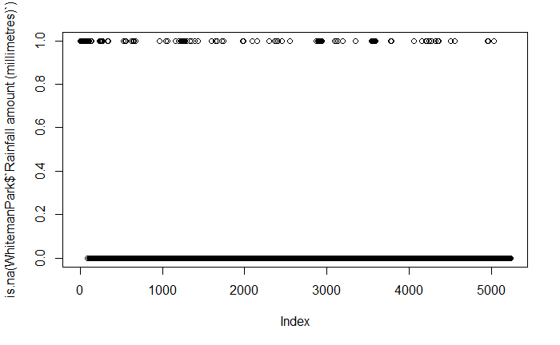

```r
# NOTE: each reading is independant of one another
plot(is.na(WhitemanPark$`Rainfall amount (millimetres)`))
```

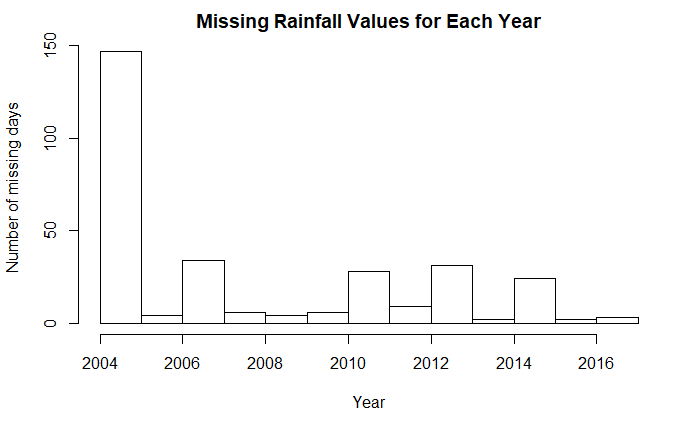

```r
# How many missing rainfall entries are there for each year?
# a histogram that finds which rainfall amounts for any year are missing
hist(WhitemanPark$Year[which(is.na(WhitemanPark$`Rainfall amount (millimetres)`)==TRUE)], main = 'Missing Rainfall Values for Each Year', xlab = 'Year', ylab = 'Number of missing days')
```

```r
table(WhitemanPark$Year[which(is.na(WhitemanPark$`Rainfall amount (millimetres)`)==TRUE)])
```

```
2004 2005 2006 2007 2008 2009 2010 2011 2012 2013 2014 2015 2016 2017
 123   24    4   34    6    4    6   28    9   31    2   24    2    3
```

From the table above, we can see that 2014 and 2016 have only 2 missing values. This large amount of data for these two years can give us a strong training and test set. We could, in theory train on the 2014 data and test on the 2016

We will now use a for loop to write the last n days of data to n columns for any given day. This will mean that our dataset will be 2n observations smaller (we are ‘chopping off’ n days from the head and tail)

The lag days can be done before cleaning the data; we can just set an NA value to the last *given* day. Alternatively, we can set the lag to NA if there isn’t a value for a previous day

```r
# Writing the year, the last n days of data, the mean of those n days, the current day, and a rain state boolean
# This part of the project is based on Workshop 10; created by Aloke
# setting the lag columns and mean to zero
# unfortunately, the lag() function doesn't pad the head and tail with NA; as it is, it has no effect on the data frame
# as a result, the lags will be written in a seperate code chunk
# Note that we can also set the repeated value to NA; rep(NA)
WP.lag <- data.frame(Year = WhitemanPark$Year, Month = WhitemanPark$Month, Day = WhitemanPark$Day, Today = WhitemanPark$`Rainfall amount (millimetres)`, Lag1 = rep(0), Lag2 = rep(0), Lag3 = rep(0), Lag4 = rep(0), Lag5 = rep(0), Lag6 = rep(0), Lag7 = rep(0), MeanLag = rep(0), MedLag = rep(0), RainState = (WhitemanPark$`Rainfall amount (millimetres)`> 0))
# updated draft version
#WP.lag <- data.frame(Year = WhitemanPark$Year, Month = WhitemanPark$Month, Day = WhitemanPark$Day, Today = WhitemanPark$`Rainfall amount (millimetres)`, Lag1 = rep(0), Lag2 = rep(0), Lag3 = rep(0), Lag4 = rep(0), Lag5 = rep(0), Lag6 = rep(0), Lag7 = rep(0), MeanLag = rep(0), MedLag = median(as.numeric(WP.lag[i,5:11]),na.rm=TRUE), RainState = (WhitemanPark$`Rainfall amount (millimetres)`> 0))
```

Note that RainState is a boolean that outputs TRUE if there has been any rain (> 0) and FALSE if not (== 0). The beaureu of meteorology (BOM) discard any readings less than 0.2mm; as moisture/humidity can give false readings.

```r
# for every entry
# write the previous entry to the current entry
#for (i in 1:7){
#  WP.lag[4+i,(i+2):nrow(WhitemanPark)] <- WhitemanPark$`Rainfall amount (millimetres)`[-i]
#}
WP.lag$Lag1[3:nrow(WhitemanPark)] <- WhitemanPark$`Rainfall amount (millimetres)`[-1]
```

```
number of items to replace is not a multiple of replacement length
```

```r
WP.lag$Lag2[4:nrow(WhitemanPark)] <- WhitemanPark$`Rainfall amount (millimetres)`[-2]
```

```
number of items to replace is not a multiple of replacement length
```

```r
WP.lag$Lag3[5:nrow(WhitemanPark)] <- WhitemanPark$`Rainfall amount (millimetres)`[-3]
```

```
number of items to replace is not a multiple of replacement length
```

```r
WP.lag$Lag4[6:nrow(WhitemanPark)] <- WhitemanPark$`Rainfall amount (millimetres)`[-4]
```

```
number of items to replace is not a multiple of replacement length
```

```r
WP.lag$Lag5[7:nrow(WhitemanPark)] <- WhitemanPark$`Rainfall amount (millimetres)`[-5]
```

```
number of items to replace is not a multiple of replacement length
```

```r
WP.lag$Lag6[8:nrow(WhitemanPark)] <- WhitemanPark$`Rainfall amount (millimetres)`[-6]
```

```
number of items to replace is not a multiple of replacement length
```

```r
WP.lag$Lag7[9:nrow(WhitemanPark)] <- WhitemanPark$`Rainfall amount (millimetres)`[-7]
```

```
number of items to replace is not a multiple of replacement length
```

```r
# The mean of the 5th to the 11th columns
# The number of missing values in a given row
# sum(is.na(WP.lag[626,3:9]))
# so to calculate the mean, we'd have 7-sum(is.na(WP.lag[626,3:9]))
# for each row in the dataset,
for (i in 1:nrow(WP.lag)){
  # divide the sum of the values in the row by the number of columns - missing columns
  #na.rm = TRUE means that NA values will be removed
  WP.lag$MeanLag[i] <- sum(WP.lag[i,5:11],na.rm = TRUE)/(7-sum(is.na(WP.lag[i,5:11])))
}
# for each row in the dataset,
for (i in 1:nrow(WP.lag)){
  sort
  # output the median of the values
  #na.rm = TRUE means that NA values will be removed
  WP.lag$MedLag[i] <- median(as.numeric(WP.lag[i,5:11]),na.rm=TRUE)
}
```

```r
# turning rainstate into factors, for the glm
WP.lag$RainState <- factor(WP.lag$RainState)
```

```r
# GABES CODE
WP.lag.clean <- WP.lag[complete.cases(WP.lag),]
#Check for all rows where Rainfall_mm has values other than NA
#Saves them into a new dataset
#Training
WP.lag.2014 <- WP.lag.clean[which(WP.lag.clean$Year == 2014),]
# QUICK EDA
# these are the rows which have an NA VALUE FOR 'TODAY'
#WP.lag.2014 <- WP.lag.2014[-which(is.na(WP.lag.2014$Today)),]
# Test
WP.lag.2016 <- WP.lag.clean[which(WP.lag.clean$Year == 2016),]
#WP.lag.2016 <- WP.lag.2016[-which(is.na(WP.lag.2016$Today)),]
```

```r
# DONT ADD TODAY's DATA TO THE LINEAR MODEL!!! IT WILL WORK WITH 100% ACCURACY, BECAUSE
levels(WP.lag.2014$RainState)
```

```
[1] "FALSE" "TRUE"
```

```r
WP.lag.2014.glm <- glm(RainState ~ Lag1 + Lag2 + Lag3 + Lag4 + Lag5 + Lag6 + Lag7 + MeanLag, data = WP.lag, family = binomial(logit))
# NOTE: IF YOU ADD MEANLAG, ALONGSIDE LAG1 TO LAG 7, IT WILL HAVE ZERO EFFECT
WP.lag.2014.glm <- glm(RainState ~ Day+Lag1+Lag2+Lag3+Lag4+Lag5+Lag6+MeanLag, data = WP.lag.clean, family = binomial(logit))
WP.lag.2014.glm
```

```
Call:  glm(formula = RainState ~ Day + Lag1 + Lag2 + Lag3 + Lag4 + Lag5 +
    Lag6 + MeanLag, family = binomial(logit), data = WP.lag.clean)

Coefficients:
(Intercept)        Day02        Day03        Day04        Day05        Day06        Day07
  -1.622054    -0.346869    -0.522085    -0.581455     0.048375    -0.251564     0.075985
      Day08        Day09        Day10        Day11        Day12        Day13        Day14
  -0.238470    -0.318868    -0.221623    -0.050042    -0.017156    -0.075781    -0.560517
      Day15        Day16        Day17        Day18        Day19        Day20        Day21
  -0.438957    -0.395333    -0.314149     0.296551    -0.184548    -0.089588     0.177019
      Day22        Day23        Day24        Day25        Day26        Day27        Day28
   0.100968    -0.098457    -0.685245    -0.240605    -0.454175    -0.027688     0.208009
      Day29        Day30        Day31         Lag1         Lag2         Lag3         Lag4
  -0.089544     0.414328     0.295975     0.115738     0.004855    -0.009819    -0.002782
       Lag5         Lag6      MeanLag
  -0.009571    -0.009568     0.159594

Degrees of Freedom: 4412 Total (i.e. Null);  4375 Residual
Null Deviance:      4726
Residual Deviance: 4135     AIC: 4211
```

```r
# exactly the same, but it adds the date parameters to the glm
# IMPORTANT
# Note that the month and day parameters add 12 + 31 parameters into the glm. This means that our glm will
WP.lag.2014.withdates.glm <- glm(RainState ~ Lag1 + Lag2 + Lag3 + Lag4 + Lag5 + Lag6 + Lag7 + MeanLag + MedLag, data = WP.lag, family = binomial(logit))
# making predictions
WP.predict <- predict(WP.lag.2014.glm, newdata = WP.lag.2016, type = "response")
head(WP.predict)
```

```
      4384       4385       4386       4387       4388       4389
0.16492182 0.12250462 0.10488022 0.09943581 0.17169264 0.13312369
```

```r
# making predictions but with the date parameters
WP.withdates.predict <- predict(WP.lag.2014.withdates.glm, newdata = WP.lag.2016, type = "response")
```

```
prediction from a rank-deficient fit may be misleading
```

```r
head(WP.withdates.predict)
```

```
     4384      4385      4386      4387      4388      4389
0.1477617 0.1477617 0.1477617 0.1477617 0.1477617 0.1477617
```

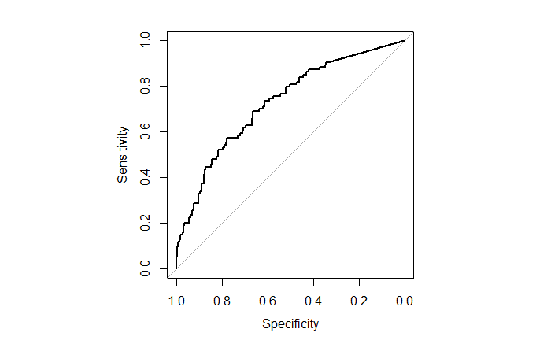

```r
# plotting ROC curve
library(pROC)
#square graph
par(pty = "s")
plot(roc(WP.lag.2016$RainState, WP.withdates.predict,legacy.axes = TRUE))
```

```r
levels(WP.lag.2014$RainState)
```

```
[1] "FALSE" "TRUE"
```

```r
# using just the date to predict the next day of rain
WP.lag.2014.glm.version2 <- glm(RainState ~ Month+Day, data = WP.lag.2014, family = binomial(logit))
```

```
glm.fit: fitted probabilities numerically 0 or 1 occurred
```

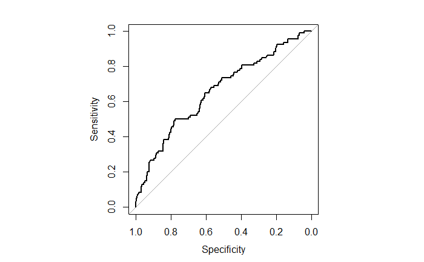

```r
WP.withdates.predict.version2 <- predict(WP.lag.2014.glm.version2, newdata = WP.lag.2016, type = "response")
# plotting ROC curve
library(pROC)
#square graph
par(pty = "s")
plot(roc(WP.lag.2016$RainState, WP.withdates.predict.version2,legacy.axes = TRUE))
```

```r
# Summaries of the glms
summary(WP.lag.2014.glm)
```

```
Call:
glm(formula = RainState ~ Day + Lag1 + Lag2 + Lag3 + Lag4 + Lag5 +
    Lag6 + MeanLag, family = binomial(logit), data = WP.lag.clean)

Deviance Residuals:
    Min       1Q   Median       3Q      Max
-4.0442  -0.6506  -0.5570  -0.4577   2.1919

Coefficients:
             Estimate Std. Error z value Pr(>|z|)
(Intercept) -1.622054   0.207212  -7.828 4.96e-15 ***
Day02       -0.346869   0.303541  -1.143 0.253145
Day03       -0.522085   0.317575  -1.644 0.100181
Day04       -0.581455   0.318996  -1.823 0.068339 .
Day05        0.048375   0.290541   0.167 0.867762
Day06       -0.251564   0.300728  -0.837 0.402864
Day07        0.075985   0.291612   0.261 0.794425
Day08       -0.238470   0.302652  -0.788 0.430736
Day09       -0.318868   0.305668  -1.043 0.296863
Day10       -0.221623   0.303944  -0.729 0.465906
Day11       -0.050042   0.294571  -0.170 0.865103
Day12       -0.017156   0.292368  -0.059 0.953207
Day13       -0.075781   0.296149  -0.256 0.798037
Day14       -0.560517   0.318897  -1.758 0.078803 .
Day15       -0.438957   0.308700  -1.422 0.155040
Day16       -0.395333   0.309238  -1.278 0.201104
Day17       -0.314149   0.304030  -1.033 0.301473
Day18        0.296551   0.279784   1.060 0.289177
Day19       -0.184548   0.295127  -0.625 0.531764
Day20       -0.089588   0.294965  -0.304 0.761339
Day21        0.177019   0.286125   0.619 0.536128
Day22        0.100968   0.290153   0.348 0.727854
Day23       -0.098457   0.297910  -0.330 0.741028
Day24       -0.685245   0.326319  -2.100 0.035736 *
Day25       -0.240605   0.303661  -0.792 0.428158
Day26       -0.454175   0.313030  -1.451 0.146807
Day27       -0.027688   0.292023  -0.095 0.924462
Day28        0.208009   0.283880   0.733 0.463719
Day29       -0.089544   0.297781  -0.301 0.763639
Day30        0.414328   0.283110   1.463 0.143334
Day31        0.295975   0.322419   0.918 0.358627
Lag1         0.115738   0.010845  10.672  < 2e-16 ***
Lag2         0.004855   0.008768   0.554 0.579781
Lag3        -0.009819   0.008605  -1.141 0.253836
Lag4        -0.002782   0.008696  -0.320 0.749067
Lag5        -0.009571   0.008798  -1.088 0.276694
Lag6        -0.009568   0.009320  -1.027 0.304620
MeanLag      0.159594   0.041298   3.864 0.000111 ***
---
Signif. codes:  0 ‘***’ 0.001 ‘**’ 0.01 ‘*’ 0.05 ‘.’ 0.1 ‘ ’ 1

(Dispersion parameter for binomial family taken to be 1)

    Null deviance: 4725.6  on 4412  degrees of freedom
Residual deviance: 4135.2  on 4375  degrees of freedom
AIC: 4211.2

Number of Fisher Scoring iterations: 5
```

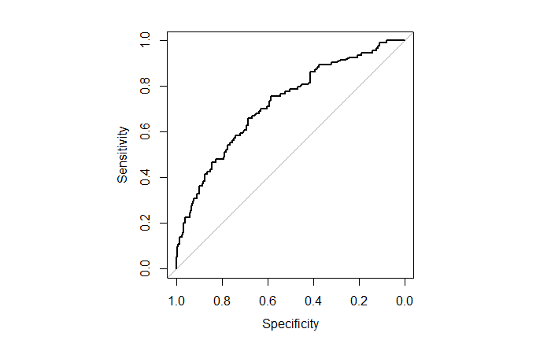

```r
#summary(WP.lag.2014.withdates.glm)
# creating a confusion matrix using the last week of data
WP.predict.class <- rep("No Rain", length(WP.lag.2014.glm))
WP.predict.class[WP.predict > 0.5] <- "Rain"
#table(WP.predict.class, WP.lag.2016$RainState)
# creating a confusion matrix using the date and the last week of data
# IMPORTANT
# Note that when adding the dates, our predictions that it won't rain when it will (Rain FALSE) are wrong more, but our True positive (Rain TRUE) is significantly larger
# IMPORTANT
# What is interesting is that these extra parameters don't change the accuracy of predicting when it won't rain (Both tables' first row (No rain) is 25 and 6 for False and True)
WP.withdates.predict.class <- rep("No Rain", length(WP.lag.2014.withdates.glm))
WP.withdates.predict.class[WP.withdates.predict > 0.5] <- "Rain"
#table(WP.withdates.predict.class, WP.lag.2016$RainState)
# plotting ROC curve
library(pROC)
#square graph
par(pty = "s")
plot(roc(WP.lag.2016$RainState, WP.predict,legacy.axes = TRUE))
# plotting with the date parameters
par(pty = "s")
```

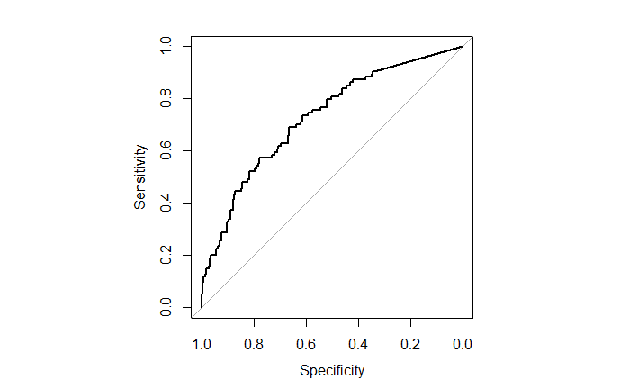

```r
plot(roc(WP.lag.2016$RainState, WP.withdates.predict,legacy.axes=TRUE))
```

```r
WP.neuralnet <- neuralnet(Today ~ Lag1+Lag2+Lag3+Lag4+Lag5+Lag6+Lag7+MeanLag+MedLag,data=WP.lag.2014,hidden = c(3,1),stepmax=3e+10)
```

```
NAs introduced by coercion to integer rangeError: 'stepmax' must be an integer
```

```r
# quick glm plot attempt
# maybe I could do:
# data = WP.lag[which(WP.lag$Year == 2014),]
levels(WP.lag$RainState)
```

```
[1] "FALSE" "TRUE"
```

```r
summary(glm(RainState ~ Lag1 + Lag2 + Lag3 + Lag4 + Lag5 + Lag6 + Lag7 + MeanLag, data = WP.lag, family = binomial(logit)))
```

```
Call:
glm(formula = RainState ~ Lag1 + Lag2 + Lag3 + Lag4 + Lag5 +
    Lag6 + Lag7 + MeanLag, family = binomial(logit), data = WP.lag)

Deviance Residuals:
       Min          1Q      Median          3Q         Max
-3.9204918  -0.6101644  -0.5670240  -0.5670240   1.9530268

Coefficients: (1 not defined because of singularities)
                Estimate   Std. Error   z value               Pr(>|z|)
(Intercept) -1.746398792  0.048828208 -35.76619 < 0.000000000000000222 ***
Lag1         0.137479112  0.009027405  15.22909 < 0.000000000000000222 ***
Lag2         0.026384489  0.006245542   4.22453            0.000023944 ***
Lag3         0.012810028  0.006045583   2.11891             0.03409831 *
Lag4         0.018574445  0.006126617   3.03176             0.00243131 **
Lag5         0.012997932  0.006174429   2.10512             0.03528062 *
Lag6         0.013410998  0.006149850   2.18070             0.02920536 *
Lag7         0.022182835  0.005826534   3.80721             0.00014054 ***
MeanLag               NA           NA        NA                     NA
---
Signif. codes:  0 ‘***’ 0.001 ‘**’ 0.01 ‘*’ 0.05 ‘.’ 0.1 ‘ ’ 1

(Dispersion parameter for binomial family taken to be 1)

    Null deviance: 4725.5932  on 4412  degrees of freedom
Residual deviance: 4182.9667  on 4405  degrees of freedom
  (814 observations deleted due to missingness)
AIC: 4198.9667

Number of Fisher Scoring iterations: 5
```

```r
summary(glm(RainState ~ Lag1 + Lag2 + Lag3 + Lag4 + Lag5 + Lag6 + Lag7 + MeanLag, data = WP.lag.clean, family = binomial(logit)))
```

```
Call:
glm(formula = RainState ~ Lag1 + Lag2 + Lag3 + Lag4 + Lag5 +
    Lag6 + Lag7 + MeanLag, family = binomial(logit), data = WP.lag.clean)

Deviance Residuals:
       Min          1Q      Median          3Q         Max
-3.9204918  -0.6101644  -0.5670240  -0.5670240   1.9530268

Coefficients: (1 not defined because of singularities)
                Estimate   Std. Error   z value               Pr(>|z|)
(Intercept) -1.746398792  0.048828208 -35.76619 < 0.000000000000000222 ***
Lag1         0.137479112  0.009027405  15.22909 < 0.000000000000000222 ***
Lag2         0.026384489  0.006245542   4.22453            0.000023944 ***
Lag3         0.012810028  0.006045583   2.11891             0.03409831 *
Lag4         0.018574445  0.006126617   3.03176             0.00243131 **
Lag5         0.012997932  0.006174429   2.10512             0.03528062 *
Lag6         0.013410998  0.006149850   2.18070             0.02920536 *
Lag7         0.022182835  0.005826534   3.80721             0.00014054 ***
MeanLag               NA           NA        NA                     NA
---
Signif. codes:  0 ‘***’ 0.001 ‘**’ 0.01 ‘*’ 0.05 ‘.’ 0.1 ‘ ’ 1

(Dispersion parameter for binomial family taken to be 1)

    Null deviance: 4725.5932  on 4412  degrees of freedom
Residual deviance: 4182.9667  on 4405  degrees of freedom
AIC: 4198.9667

Number of Fisher Scoring iterations: 5
```

# IMPORTANT

We can use tapply to calcualte the mean rainfall of the previous n days

```r
# WP.lag$LagMean <- tapply(Lag1:Lag5, mean)
```